# hw4

Xinrui Zhang UID:605231530

## P2

1. Strict Stationarity The joint distribution of any moments of any degree is always all the same and never depend on location. No trend, the distribution shape won’t change, just like white noise.
2. Intrinsic Stationarity For instrisic stationarity, a mean is assumed constant between location, the variance of the difference is the same between any two points that are at same distance and diretion apart no matter which two points are chosen.

$$E[s(x+h) - s(x)]=0$$

$$Var[s(x+h)-s(h)]=2\gamma(h)$$

3. Second-Order Stationarity Second-order stationarity is a special type of intrinsic stationarity, where the covariance between two points is the same for a certain distance and direction, regardless where those two points locate. Second-order sationarity must also be a intrinsic stationarity, but intrinsic stationarity is not necessarily a second-order staionarity.

$$E(s(x))=\mu$$

$$E[(s(x)-\mu)^2]=\sigma^2$$

$$Cov[s(x), s(x+h)] = E[(s(x)-\mu)(s(x+h)-\mu)]=C(h)$$

## P3

$$\gamma(h)=\frac{1}{2}var(Y(s+h)-Y(h))$$

$$\gamma(h)=\frac{1}{2}(var(Y(s+h))+var(Y(s))-2E[(Y(s)-E(Y(s)))(Y(s+h)-E(Y(s+h)))])$$

$$\gamma(h)=\frac{1}{2}(C(0)+C(0)-2E[cov(Y(s+h),Y(s))])$$

$$\gamma(h)=\frac{1}{2}(2C(0)-2C(h))$$

$$\gamma(h)=C(0)-C(h)$$

## P4

```r
#data read-in
Temp <- read.csv('tmax_01feb2019.csv')
Temp %>% filter(lat >= 32 & lat <= 36) %>%
  filter(lon >= -119 & lon <= -115) -> Temp

TempO <- Temp[is.na(Temp$TMAX) == F, ] #observed temperature
```

```r
#linear regression to define mean function (funcation of elevation)
lm1 <- lm(TempO$TMAX ~ TempO$elev)
summary(lm1)
```

```
##
## Call:
## lm(formula = TempO$TMAX ~ TempO$elev)
##
## Residuals:
##     Min      1Q  Median      3Q     Max
## -6.1926 -1.5546 -0.3779  1.2342  8.8754
##
## Coefficients:
##               Estimate Std. Error t value Pr(>|t|)
## (Intercept) 18.3926259  0.3043607   60.43   <2e-16 ***
## TempO$elev  -0.0048267  0.0003259  -14.81   <2e-16 ***
## ---
## Signif. codes:  0 '***' 0.001 '**' 0.01 '*' 0.05 '.' 0.1 ' ' 1
##
## Residual standard error: 2.278 on 139 degrees of freedom
## Multiple R-squared:  0.6121, Adjusted R-squared:  0.6093
## F-statistic: 219.3 on 1 and 139 DF,  p-value: < 2.2e-16
```

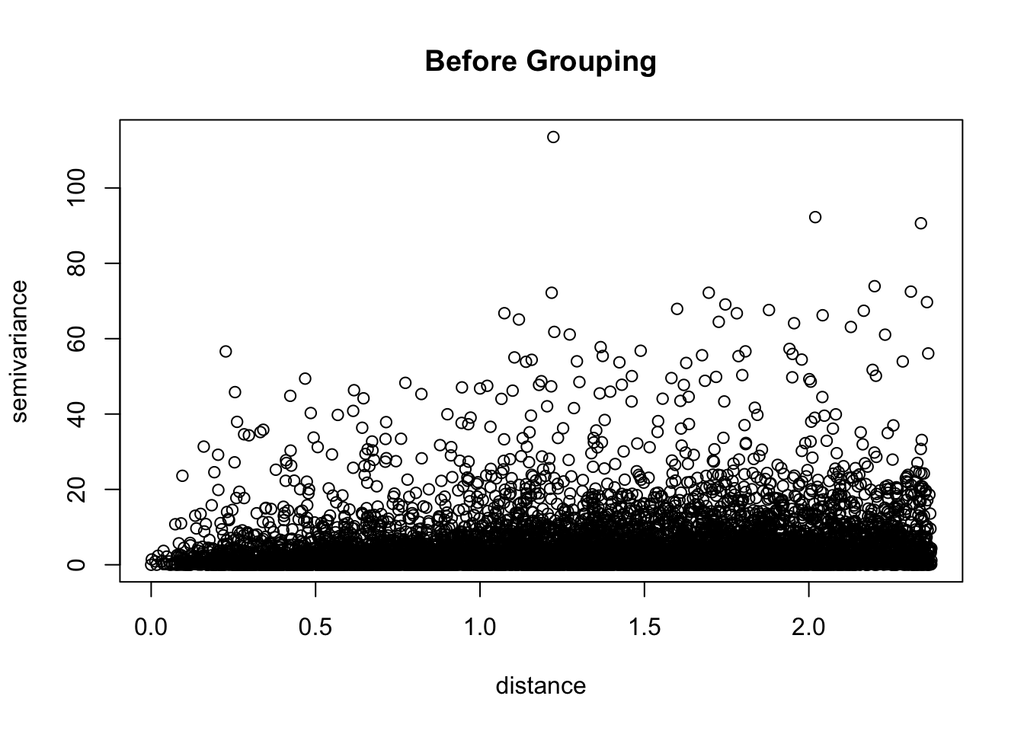

```r
#errors
e <- TempO$TMAX -(TempO$elev * lm1$coefficients[2] + lm1$coefficients[1])
semiv <- c() # vector to store semivariance
h <- c()  # vector to store lag
nO <- nrow(TempO)#number of observations
for (i in (1 : nO-1)){
  for (j in (2 : nO)){
   semivi <- (e[i] - e[j])^2/2
   hi <- sqrt((TempO$lat[i] - TempO$lat[j]) ^ 2 + (TempO$lon[i] - TempO$lon[j]) ^ 2 )
   semiv <- c(semiv, semivi)
   h <- c(h, hi)
  }
}

# drop duplicate value and rank lags
variog <- data.frame(semiv, h)
variog %>% filter(h <= max(h)/2) %>%  #cutoff at h=max(h)/2
  arrange(desc(h)) -> variog
variog %>% group_by(h) %>%
  dplyr :: summarise(semiv = mean(semiv)) -> variog

plot(variog$h, variog$semiv,
     ylab = 'semivariance',
     xlab = 'distance', main = 'Before Grouping')
```

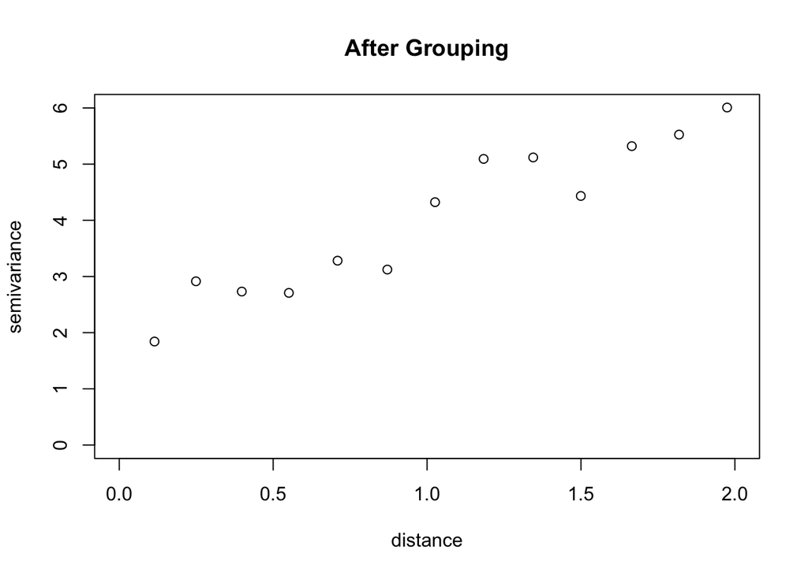

```r
#group lags
width <- max(h)/2/15
group <- c()
for (j in (1 : 15)){ #15 groups in total
  for(i in (1 : nrow(variog))){
    if (variog$h[i] <= min(h) + j * width & variog$h[i] >= min(h) + (j - 1) * width){
    group <- c(group, j)
  }
  }
}
variog$group <- group

group_size <- tapply(variog$group,
                     as.factor(variog$group), length)
variog %>% group_by(group) %>%
  dplyr :: summarise(h = median(h),
                     semiv = mean(semiv)) -> variogAVE

#plot empirical variogram
plot(variogAVE$h, variogAVE$semiv,
     ylab = 'semivariance',
     xlab = 'distance',
     xlim = c(0, 2),
     ylim = c(0, 6), main = 'After Grouping')
```

```r
# fit variogram by software and see the fitted parameters
v <- variogram(object = TMAX ~ elev, locations = ~ lon + lat, data = TempO)

v1_fit <- fit.variogram(v, vgm(model ='Sph' ,
                               psill = 4,
                               nugget = 1.8,
                               range = 1.8))
v1_fit
```

```
##   model    psill    range
## 1   Nug 1.814951 0.000000
## 2   Sph 4.895614 3.179788
```

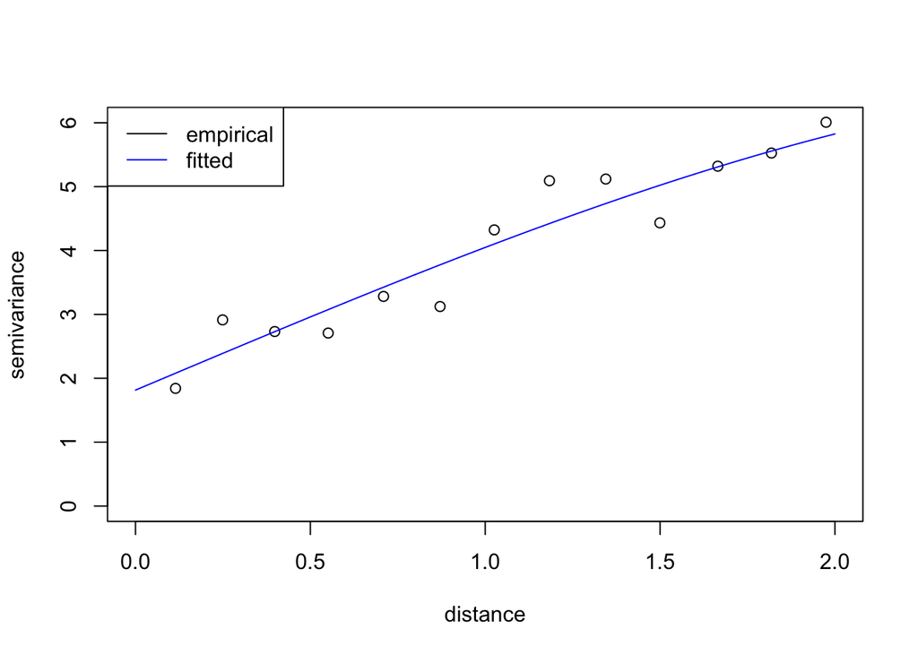

```r
# built model using fitted parameters
variogram <- function(h){
  semi <- c()
 for (i in 1:length(h)){
   if (h[i] <= v1_fit$range[2]){
     semi[i] <- v1_fit$psill[1] + v1_fit$psill[2]  * (3*h[i]/2/(v1_fit$range[2])-h[i]^3/2/(v1_fit$range[2]^3))
   }else{
     semi[i] <- v1_fit$psill[1] + v1_fit$psill[2]
   }
 }
  return(semi)
}

#check the model
fited <- seq(from = 0, to = 2, length = 1000)
plot(variogAVE$h, variogAVE$semiv,
     ylab = 'semivariance',
     xlab = 'distance',
     xlim = c(0, 2),
     ylim = c(0, 6))
lines(fited, variogram(fited), type="l", col="blue")
legend('topleft', c('empirical', 'fitted'), lty = c(1,1),
       col = c('black', 'blue'), cex = 1)
```

```r
# store parameters
variogram_par <- c(v1_fit$psill[1], v1_fit$psill[2], v1_fit$range[2])
```

```r
# leave 20 station out for testing
out_index <- which(is.na(match(Temp$id, TempO$id[1:20])) == F)
TempOl <- TempO[-(1:20),] #leave 20 out

# get covariance matrix
sigmaM <- matrix(0, nrow = nrow(TempOl), ncol = nrow(TempOl))

for(i in 1:nrow(TempOl)){
  for(j in i:nrow(TempOl)){
    h <- sqrt((TempOl$lat[i] - TempOl$lat[j]) ^ 2 + (TempOl$lon[i] - TempOl$lon[j]) ^ 2)
    sigmai <- (variogram_par[1] + variogram_par[2]) - variogram(h)
    sigmaM[i, j] <- sigmai
    sigmaM[j, i] <- sigmai
  }
}

# matrix for calculation, elevation is the preditor
TempOl %>% select(elev) %>%
  as.matrix() -> XO

# check mean function e
beta_wls <- solve(t(XO) %*% solve(sigmaM) %*% XO) %*% t(XO) %*% solve(sigmaM) %*% as.matrix(TempOl$TMAX) #weighted least squares
beta_wls
```

```
##              [,1]
## elev -0.004900365
```

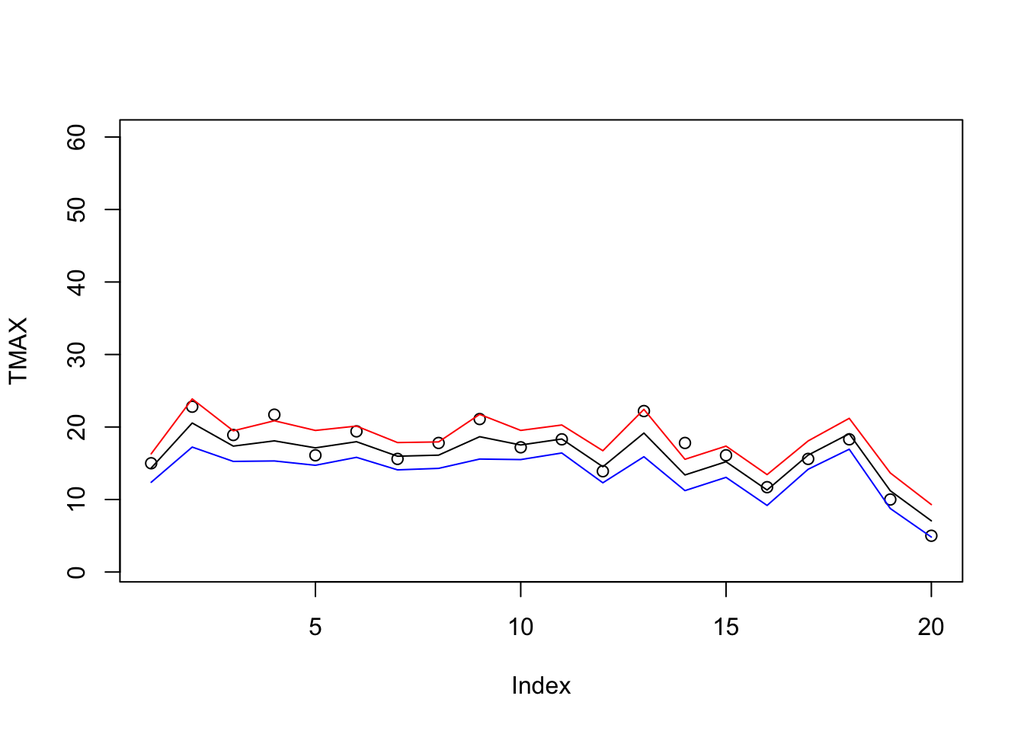

```r
# gamma matrices
gammaM <- matrix(0, nrow = nrow(TempOl), ncol = nrow(TempOl))

for(i in 1:nrow(XO)){
  for(j in i:nrow(XO)){
    h <- sqrt((TempOl$lat[i] - TempOl$lat[j])^2 + (TempOl$lon[i] - TempOl$lon[j])^2)
    gami <- variogram(h)
    gammaM[i, j] <- gami
    gammaM[j, i] <- gami
  }
}

#Temppre <- Temp
#Temppre$TMAX[out_index]

Temp %>% select(elev) %>%
  as.matrix() -> Xpre

Xpre <- as.matrix(Temp$elev)

gammaPRE <- matrix(0, nrow=nrow(XO), ncol=nrow(Temp))

for(i in 1:nrow(XO)){
  for(j in 1:nrow(Temp)){
    h <- sqrt((TempOl$lat[i] - Temp$lat[j])^2 + (TempOl$lon[i] - Temp$lon[j])^2)
    gam <- variogram(h)
    gammaPRE[i, j] <- gam
  }
}

prediction <- c()
predicted_var <- c()
gammaI <- solve(gammaM)
A <- solve(t(XO) %*% solve(gammaM) %*% XO)

for(i in 1:nrow(Temp)){
  # covariates and gamma vector
  gamma0 <- as.matrix(gammaPRE[, i])
  x0 <- as.matrix(as.vector(t(Xpre[i, ])))

  # prediction
  pred_1 <- XO %*% A %*% (x0 - t(XO) %*% gammaI %*% gamma0)
  pred <- t(gamma0 + pred_1) %*% gammaI %*% as.matrix(TempOl$TMAX)
  prediction <- c(prediction, pred)

  # variance
  var1 <- t(gamma0) %*% gammaI %*% gamma0
  var2 <- t(XO) %*% gammaI %*% gamma0 - x0
  pred_var <- var1 - t(var2) %*% A %*% var2
  predicted_var <- c(predicted_var, pred_var)
}

Temp$prediction <- prediction
Temp$var <- predicted_var

#Temp$prediction[out_index]
#TempO$TMAX[1 : 20]
plot(TempO$TMAX[1 : 20], ylim = c(1, 60),
     ylab = 'TMAX')
lines(Temp$prediction[out_index])
lines(Temp$prediction[out_index] - Temp$var[out_index],
      col = 'blue')
lines(Temp$prediction[out_index] + Temp$var[out_index],
      col = 'red')
```

```r
Temp[out_index, ]
```

```
##         X          id     lat       lon   elev TMAX prediction      var
## 295 35444 USC00040136 32.8358 -116.7775  516.6 15.0  14.336544 1.963737
## 298 35448 USC00040176 34.5592 -115.7442  197.5 22.8  20.552026 3.319450
## 299 35450 USC00040192 33.8647 -117.8425   71.6 18.9  17.365656 2.109183
## 303 35463 USC00040332 35.2111 -118.8336  137.2 21.7  18.090208 2.771691
## 314 35486 USC00040521 34.8928 -117.0219  676.7 16.1  17.123870 2.402654
## 327 35533 USC00040983 33.2558 -116.4036  246.9 19.4  17.973293 2.154936
## 338 35565 USC00041194 34.1867 -118.3481  199.6 15.6  15.971821 1.882598
## 348 35588 USC00041424 32.6264 -116.4700  801.6 17.8  16.119674 1.823693
## 355 35622 USC00041738 33.6617 -115.7206  520.0 21.1  18.663339 3.082388
## 356 35626 USC00041758 32.6400 -117.0858   17.1 17.2  17.520295 2.011943
## 369 35687 USC00042214 34.0050 -118.4139   28.0 18.3  18.347045 1.930208
## 412 35832 USC00043463 35.7269 -118.7006  957.1 13.9  14.517838 2.212081
## 421 35876 USC00043855 33.7044 -115.6289  417.6 22.2  19.164853 3.264225
## 424 35885 USC00043914 33.2372 -116.7614  823.0 17.8  13.386780 2.159498
## 426 35889 USC00043937 34.4206 -117.2661  931.2 16.1  15.211806 2.155580
## 430 35918 USC00044211 33.7572 -116.7067 1639.8 11.7  11.309733 2.125848
## 438 35935 USC00044394 34.3592 -116.5378  965.3 15.6  16.127293 1.956161
## 439 35936 USC00044405 34.1472 -116.2747  781.2 18.3  19.066498 2.130654
## 461 36001 USC00044863 34.8333 -118.8650 1089.7 10.0  11.210171 2.451466
## 470 36029 USC00045091 33.8131 -116.6419 2554.2  5.0   7.060315 2.239494
```

The model performs well I think.

From the linear regression, P-value indicates a significance, thus elevation is considered as a predictor for mean function. The mean function is as below:

$$\mu(s_i) = 18.3926259 - 0.0048267 * elevation_i$$

The variogram is fitted as a Spherical function as

$$\gamma(h)=\begin{cases}
nugget + partial. sill*(\frac{3h}{2range}-\frac{h^3}{2range^3})&h\leq range\\
nugget +partial.sill&h>range
\end{cases}$$

Initial guess of parameters is obtaind from empirical variogram. The fitted parameter is as:

```r
v1_fit
```

```
##   model    psill    range
## 1   Nug 1.814951 0.000000
## 2   Sph 4.895614 3.179788
```